# Homework 2

### Loading Libraries

```r
library(tidyverse)
```

### Formatting plots

```r
library(tidyverse)

knitr::opts_chunk$set(
  fig.width = 22,
  fig.asp = .8,
  out.width = "90%"
)

theme_set(theme_minimal() + theme(legend.position = "bottom"))

options(
  ggplot2.continuous.colour = "viridis",
  ggplot2.continuous.colour = "viridis"
)

sclae_colour_discrete = scale_color_viridis_d
scale_fill_discrete = scale_fill_viridis_d
```

# Problem 1

```r
library(p8105.datasets)
data("instacart")
```

### Instacart Dataset Descriptions

- The Instacart dataset includes 15 variables: order_id, product_id, add_to_cart_order, reordered, user_id, eval_set, order_number, order_dow, order_hour_of_day, days_since_prior_order, product_name, aisle_id, department_id, aisle, department.
- The dataset has 1384617 rows and 15 columns.
- The range of days since the prior order is (0, 30).
- The median number of items added to cart order is (7).
- The total number of times an item was reordered is 828824.

### Aisles: Count and Most Ordered

```r
instacart %>%
  summarize(
    distinct_aisles = n_distinct(aisle))
```

```
## # A tibble: 1 × 1
##   distinct_aisles
##             <int>
## 1             134
```

- There are 134 different aisles.

### Creating a plot

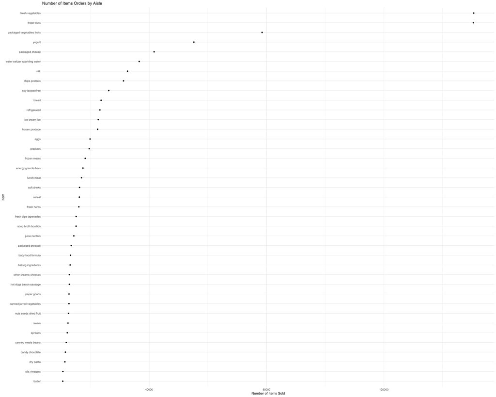

```r
instacart %>%
  count(aisle) %>%
  filter(n > 10000) %>%
  mutate(
    aisle = factor(aisle),
    aisle = fct_reorder(aisle, n)) %>%
  ggplot(aes(x = n, y = aisle)) +
  geom_point() +
  labs(
    title = "Number of Items Orders by Aisle",
    x = "Number of Items Sold",
    y = "Item"
  )
```

* The aisles where the most items are ordered from are 83 for fresh vegetables, 24 for fresh fruits, and 123 for packages vegetables fruits.

### Instacart: Cleaning and filter

```r
popular_items = instacart %>%
  filter(aisle %in% c("baking ingredients", "dog food care", "packaged vegetables fruits")) %>%
  group_by(aisle) %>%
  count(product_name) %>%
  mutate(rank = min_rank(desc(n))) %>%
  filter(rank < 4)
```

### Instacart: Table

```r
knitr::kable(head(popular_items[, 1:4]), "simple")
```

| aisle | product_name | n | rank |
| --- | --- | --- | --- |
| baking ingredients | Cane Sugar | 336 | 3 |
| baking ingredients | Light Brown Sugar | 499 | 1 |
| baking ingredients | Pure Baking Soda | 387 | 2 |
| dog food care | Organix Chicken & Brown Rice Recipe | 28 | 2 |
| dog food care | Small Dog Biscuits | 26 | 3 |
| dog food care | Snack Sticks Chicken & Rice Recipe Dog Treats | 30 | 1 |

### Icecream: Cleaning and filtering

```r
applies_icecream = instacart %>%
  filter(product_name %in% c("Pink Lady Apples", "Coffee Ice Cream")) %>%
  group_by(product_name, order_dow) %>%
  summarize(mean_hour = mean(order_hour_of_day)) %>%
  pivot_wider(
    names_from = order_dow,
    values_from = mean_hour
  )
```

### Icecream: Table

```r
knitr::kable(head(applies_icecream[, 1:8]), "simple")
```

| product_name | 0 | 1 | 2 | 3 | 4 | 5 | 6 |
| --- | --- | --- | --- | --- | --- | --- | --- |
| Coffee Ice Cream | 13.77419 | 14.31579 | 15.38095 | 15.31818 | 15.21739 | 12.26316 | 13.83333 |
| Pink Lady Apples | 13.44118 | 11.36000 | 11.70213 | 14.25000 | 11.55172 | 12.78431 | 11.93750 |

# Problem 2

```r
library(p8105.datasets)
data("brfss_smart2010")
```

### Cleaning Data

Instructions: - format the data to use appropriate variable names –> clean variable names - focus on the “Overall Health” topic –> filter for the overall health - include only responses from “Excellent” to “Poor”???? - organize responses as a factor taking levels ordered from “Poor” to “Excellent”

```r
brfss_smart2010 = brfss_smart2010 %>%
  janitor::clean_names() %>%
  filter(topic == "Overall Health") %>%
  mutate(response = str_to_lower(response),
        response = factor(response))
```

Instructions * In 2002, which states were observed at 7 or more locations? What about in 2010? - filter for 2002 - group state - count locations - find > 7 locations

- Construct a dataset that is limited to Excellent responses, and contains, year, state, and a variable that averages the data_value across locations within a state. Make a “spaghetti” plot of this average value over time within a state (that is, make a plot showing a line for each state across years – the geom_line geometry and group aesthetic will help).
- filter for “Excellent”
- select(year, state, )
- Make a “spaghetti” plot of this average value over time within a state (that is, make a plot showing a line for each state across years – the geom_line geometry and group aesthetic will help).
- Make a two-panel plot showing, for the years 2006, and 2010, distribution of data_value for responses (“Poor” to “Excellent”) among locations in NY State.

# Problem 3